# How you measure it: a survey of labor-share and corporate-profit conventions

Quarterly NIPA (and BLS) data only, 1947Q1 forward – no annual aggregation

Published

September 10, 2026

```r
library(dplyr)
library(tidyr)
library(readr)
library(ggplot2)
library(scales)
library(gt)

panel <- read_csv("../data/derived/measures_survey_quarterly.csv", show_col_types = FALSE)
meta  <- read_csv("../data/derived/measures_survey_meta.csv",      show_col_types = FALSE)
rk    <- read_csv("../data/derived/measures_survey_ranking.csv",   show_col_types = FALSE)

last_date <- max(panel$date)
last_q    <- paste0(format(last_date, "%Y"), "Q", (as.integer(format(last_date, "%m")) + 2) %/% 3)
first_q   <- paste0(format(min(panel$date), "%Y"), "Q1")

theme_ls <- function(base_size = 12) {
  theme_minimal(base_size = base_size) +
    theme(panel.grid.minor = element_blank(),
          panel.grid.major = element_line(linewidth = 0.25, colour = "grey85"),
          plot.title    = element_text(face = "bold", size = rel(1.05)),
          plot.subtitle = element_text(colour = "grey30", size = rel(0.85)),
          plot.caption  = element_text(colour = "grey45", hjust = 0, size = rel(0.72)))
}
wrp <- function(x, n = 100) paste(strwrap(x, width = n), collapse = "\n")

plot_measure <- function(id_, extreme = c("low", "high")) {
  extreme <- match.arg(extreme)
  x  <- panel |> filter(id == id_) |> arrange(date)
  mr <- meta  |> filter(id == id_)
  r  <- rk    |> filter(id == id_)
  is_index <- mr$unit == "Index, 2017=100"
  col <- if (mr$group == "Labor share") "#1B4F72" else "#B54708"

  ref_date  <- if (extreme == "low") r$record_date else r$record_high_date
  ref_value <- if (extreme == "low") r$record_value else r$record_high_value
  ref_lab   <- if (extreme == "low") "record low" else "record high"

  p <- ggplot(x, aes(date, value)) +
    geom_hline(yintercept = ref_value, linetype = "22", colour = "grey55") +
    geom_line(linewidth = 0.7, colour = col) +
    geom_point(data = x |> slice_max(date, n = 1), size = 1.8, colour = col) +
    annotate("text", x = ref_date, y = ref_value,
             label = sprintf("%s: %.1f (%s)", ref_lab, ref_value,
                              paste0(format(ref_date, "%Y"), "Q", (as.integer(format(ref_date, "%m")) + 2) %/% 3)),
             hjust = 0.05, vjust = -0.6, size = 2.9, colour = "grey35") +
    scale_x_date(breaks = seq(as.Date("1950-01-01"), last_date, by = "10 years"), date_labels = "%Y") +
    labs(title = NULL,
         subtitle = sprintf("%s | %s | latest (%s): %.1f", mr$sector, mr$basis, last_q, r$latest_value),
         x = NULL, y = mr$unit,
         caption = paste0("Source: ", mr$source, ". Quarterly, ", first_q, "-", last_q, ".")) +
    theme_ls()

  if (is_index) {
    p <- p + scale_y_continuous(labels = label_number(accuracy = 1))
  } else {
    p <- p + scale_y_continuous(labels = label_percent(scale = 1))
  }
  p
}

make_table <- function(ids, extreme = c("low", "high")) {
  extreme <- match.arg(extreme)
  d <- rk |> filter(id %in% ids) |> left_join(meta |> select(id, description), by = "id")
  d <- d[match(ids, d$id), ]
  if (extreme == "low") {
    d <- d |> transmute(Name = name, Description = description,
                         `Is it the lowest?` = lowest_label, Context = context)
  } else {
    d <- d |> transmute(Name = name, Description = description,
                         `Is it the highest?` = highest_label, Context = context_high)
  }
  d |> gt() |>
    tab_options(table.font.size = 13, data_row.padding = px(6)) |>
    cols_width(Name ~ px(170), Description ~ px(340),
               starts_with("Is it") ~ px(120), Context ~ px(340)) |>
    opt_row_striping()
}
```

Every “labor share is falling” or “labor share made a round trip” argument rests on a choice of numerator, denominator and universe that the data itself doesn’t dictate. This note lays out the choices side by side rather than picking one. It’s built to sit next to `docs/replication_and_literature.md`, which replicates and stress-tests the Tax Foundation’s own specific convention; this note instead surveys the wider menu, including the four different conventions charted (without being reconciled) in an internal deck, `draft_deck_labor_share_trend_mkonczal (2).pptx`.

**Scope.** Quarterly only, 1947Q1-2026Q2 – NIPA Table 1.10 and 1.14 are published quarterly back to 1947Q1, so that’s the full available window; nothing here is annualized. Two axes run through every measure below:

- **Gross vs. net.** Whether depreciation (consumption of fixed capital) is removed from the income base. Net is the standard correction in the literature ([Rognlie 2015](https://www.brookings.edu/wp-content/uploads/2016/07/2015a_rognlie.pdf); [Bridgman 2018](https://www.cambridge.org/core/journals/macroeconomic-dynamics/article/abs/is-labors-loss-capitals-gain-gross-versus-net-labor-shares/957C5C3D90762547B3CF4924EF34F4E9)), and changes the *level* a lot; whether it changes the *trend* is measure-specific and shown below for each one.
- **Universe.** Economy-wide (NIPA Table 1.10), the BLS’s own official nonfarm-business statistic, all corporations (NIPA Table 1.14), or nonfinancial corporations only (also Table 1.14, and the internal deck’s preferred universe since it has no proprietors’ income or imputed rent to allocate).

Every number below is a direct BEA NIPA or BLS series or ratio of them – nothing is estimated, smoothed or seasonally-readjusted beyond what BEA/BLS already publish. Full definitions and series codes are in `R/10_measures_survey.R`.

## Labor share

### Economy-wide

```r
for (id_ in c("l_gross_econ", "l_net_econ_std", "l_net_tf", "l_net_labmax", "l_net_prop75")) {
  nm <- meta$name[meta$id == id_]
  cat(sprintf("\n\n#### %s\n\n", nm))
  print(plot_measure(id_, "low"))
}
```

#### Economy-wide, gross

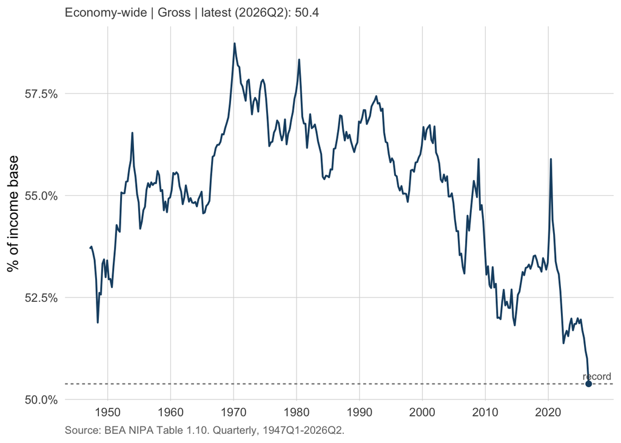

#### Economy-wide, net of depreciation

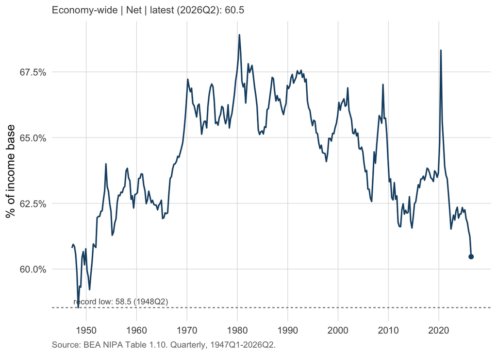

#### Economy-wide, net, proprietors’ income excluded

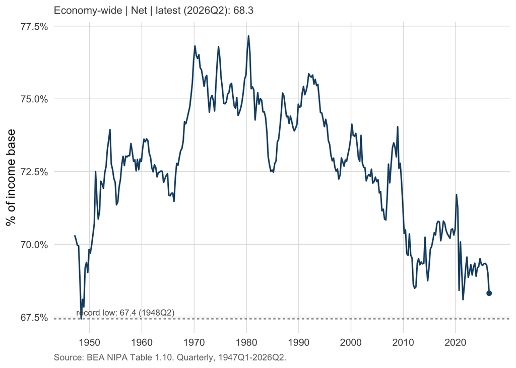

#### Economy-wide, net, all proprietors’ income to labor

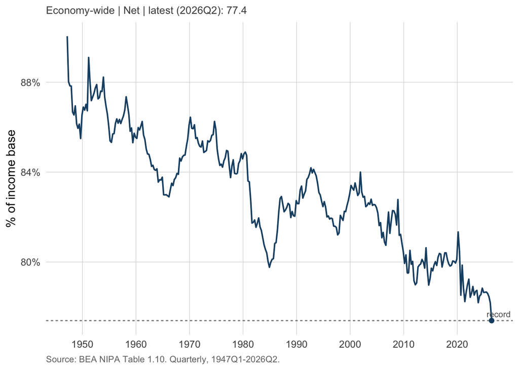

#### Economy-wide, net, 75% of proprietors’ income to labor

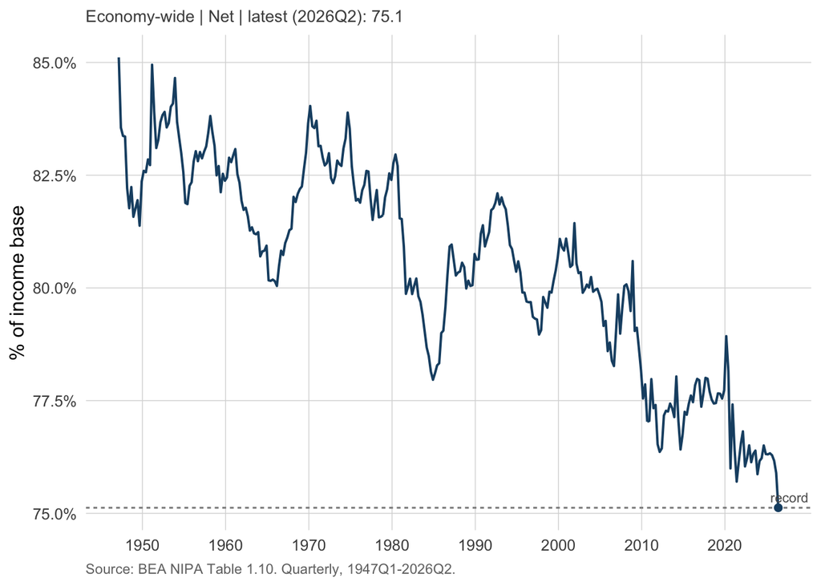

### BLS official measure

```r
cat(sprintf("\n\n#### %s\n\n", meta$name[meta$id == "l_bls_nfb"]))
```

#### BLS official measure (nonfarm business)

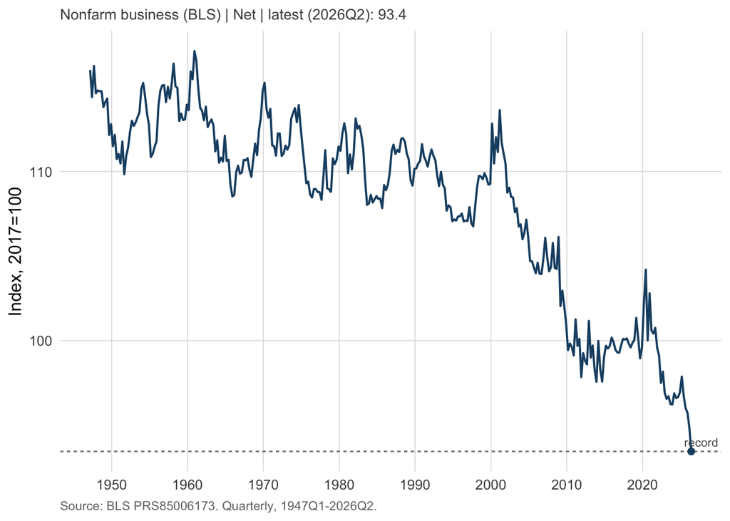

```r
print(plot_measure("l_bls_nfb", "low"))
```

Note the units: this is BLS’s own index (2017 = 100), not a percent of income. Ranking it against its own history is still meaningful – it’s a fixed-base rescaling of the same compensation-to-output ratio – but the level isn’t comparable to the percent-of-income measures above or below.

### Corporate business (all corporations)

```r
for (id_ in c("l_corp_gross", "l_corp_net_std", "l_corp_net_extax")) {
  cat(sprintf("\n\n#### %s\n\n", meta$name[meta$id == id_]))
  print(plot_measure(id_, "low"))
}
```

#### Corporate business (all corporations), gross

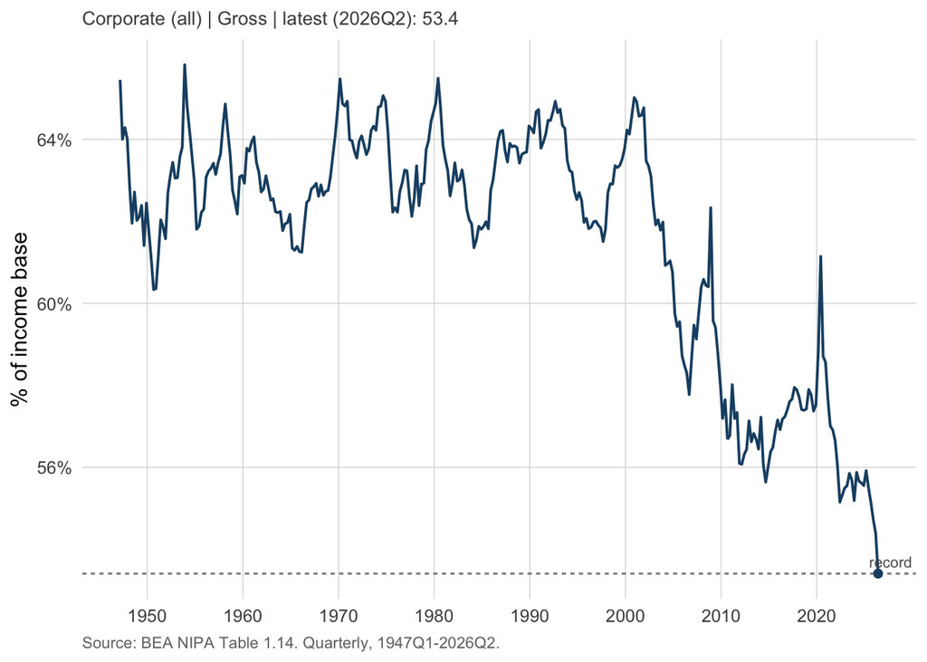

#### Corporate business (all corporations), net

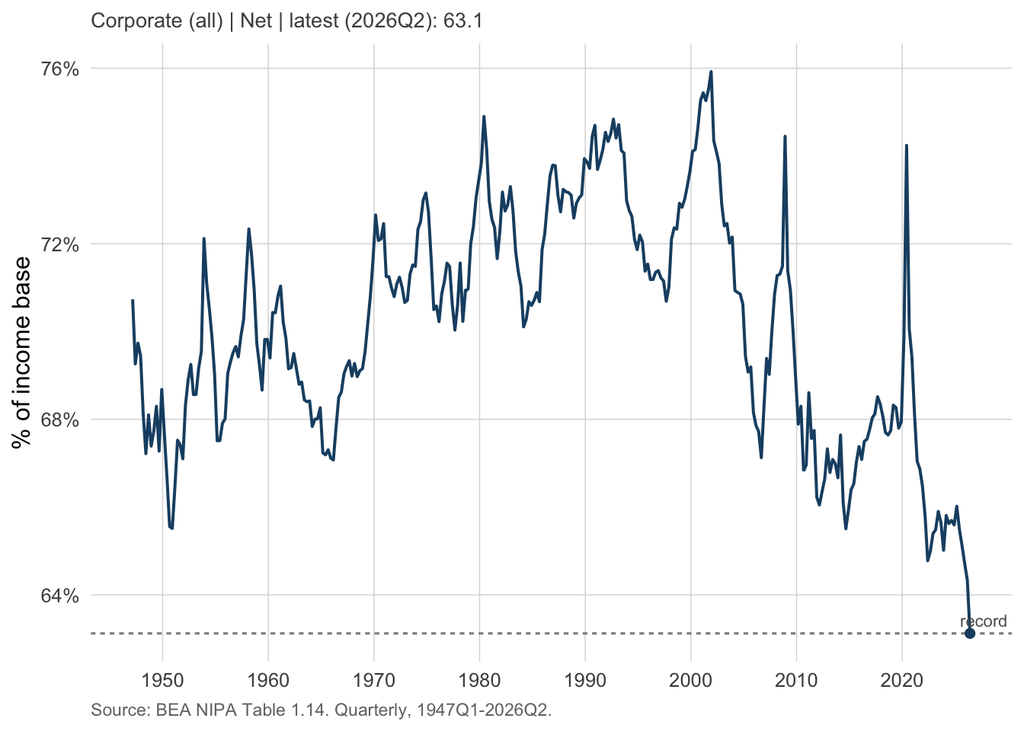

#### Corporate business (all corporations), net of production taxes

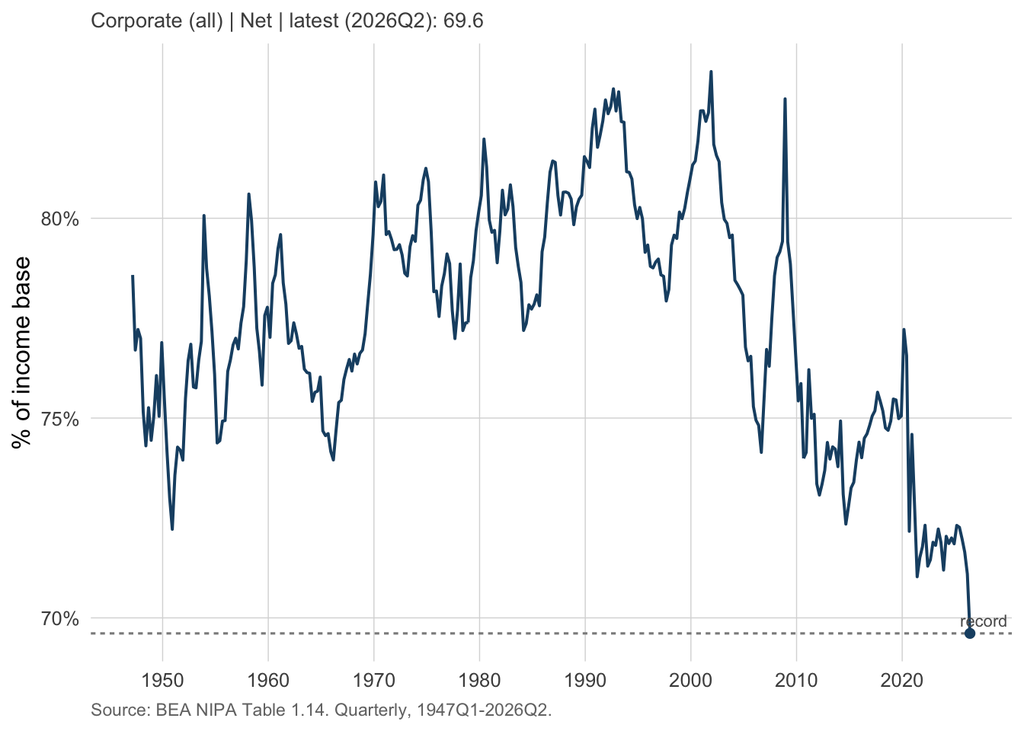

### Nonfinancial corporate business

The internal deck’s preferred universe (slides 5 and 16): no proprietors’ income, no financial-sector profits, no imputed housing rent to argue about.

```r
for (id_ in c("l_nfcorp_gross", "l_nfcorp_net_std", "l_nfcorp_net_extax")) {
  cat(sprintf("\n\n#### %s\n\n", meta$name[meta$id == id_]))
  print(plot_measure(id_, "low"))
}
```

#### Nonfinancial corporate business, gross

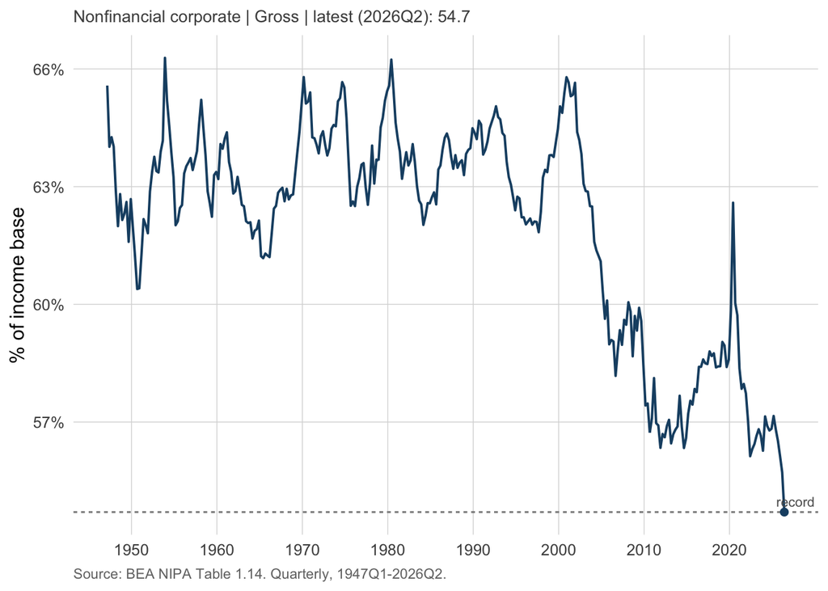

#### Nonfinancial corporate business, net

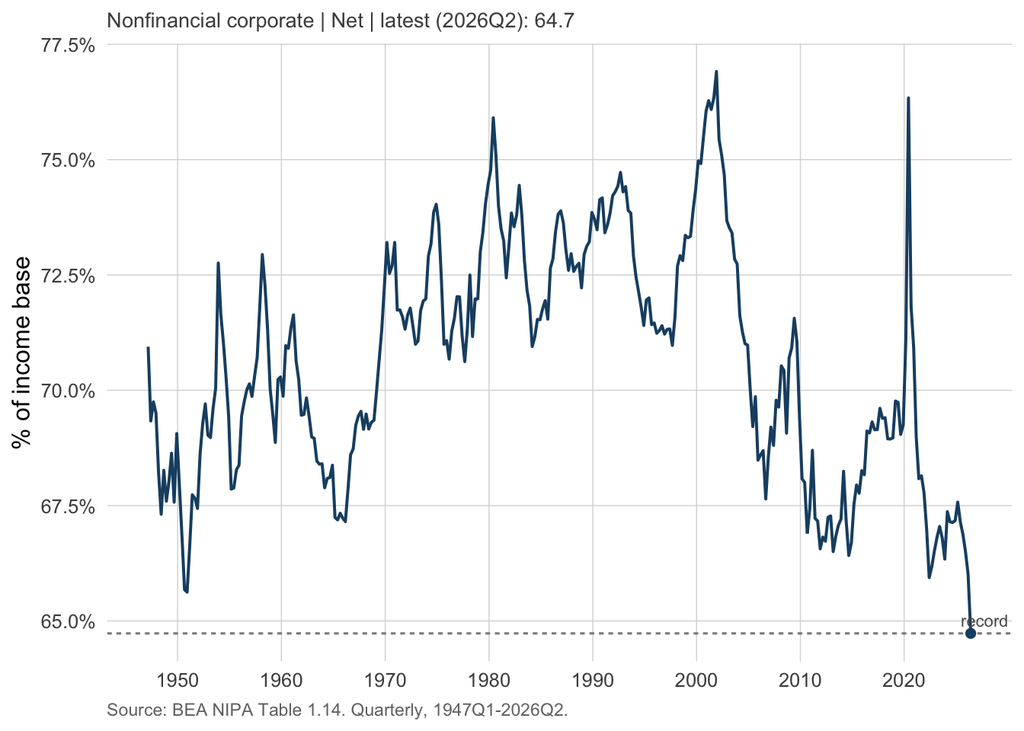

#### Nonfinancial corporate business, net of production taxes

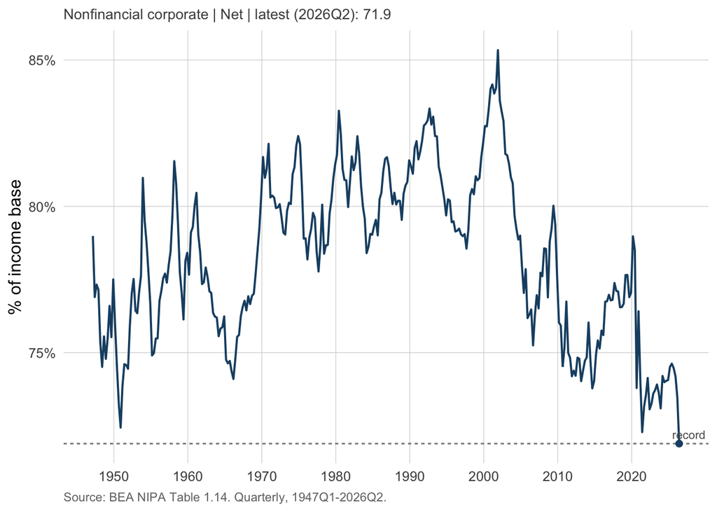

### Labor share: is it a record low?

```r
labor_order <- c("l_gross_econ", "l_net_econ_std", "l_net_tf", "l_net_labmax", "l_net_prop75",
                  "l_bls_nfb", "l_corp_gross", "l_corp_net_std", "l_corp_net_extax",
                  "l_nfcorp_gross", "l_nfcorp_net_std", "l_nfcorp_net_extax")
make_table(labor_order, "low")
```

| Name | Description | Is it the lowest? | Context |
| --- | --- | --- | --- |
| Economy-wide, gross | Compensation of employees / gross domestic income. The broadest, whole-economy measure; the denominator includes depreciation, production taxes and corporate income taxes. This is the "50-50 split" fr… | Yes - record low | Record low of the quarterly series (1947Q1-2026Q2). Previous low was 51.0 in 2026Q1, so this is 0.6 below that. |
| Economy-wide, net of depreciation | Compensation of employees / (GDI - depreciation). Removes only consumption of fixed capital, leaving production and corporate taxes in the denominator; the standard "net national income" convention in… | No | In the bottom decile of its own history (4th percentile from the bottom); 1.9 above the record low set in 1948Q2. |
| Economy-wide, net, proprietors' income excluded | Compensation / net income, where net income excludes depreciation, production taxes and corporate income taxes, and proprietors' income is treated as neither labor nor capital. This is the Tax Foundat… | No | 5th-lowest of 318 quarters since 1947Q1; 0.9 above the record low set in 1948Q2. |
| Economy-wide, net, all proprietors' income to labor | Same net-income denominator as the Tax Foundation convention, but all of proprietors' income is added to the numerator - the upper bound flagged by Gollin (2002). | Yes - record low | Record low of the quarterly series (1947Q1-2026Q2). Previous low was 78.2 in 2026Q1, so this is 0.8 below that. |
| Economy-wide, net, 75% of proprietors' income to labor | Same net-income denominator, with 75% of proprietors' income added to the numerator, following Smith, Yagan, Zidar and Zwick (2019), who attribute roughly three-quarters of pass-through profit to huma… | Yes - record low | Record low of the quarterly series (1947Q1-2026Q2). Previous low was 75.7 in 2021Q2, so this is 0.6 below that. |
| BLS official measure (nonfarm business) | BLS's own "Labor Share" series for the nonfarm business sector (PRS85006173): labor compensation / current-dollar output, indexed to 2017=100. Adds an imputed wage equivalent for roughly half of propr… | Yes - record low | Record low of the quarterly series (1947Q1-2026Q2). Previous low was 94.8 in 2026Q1, so this is 1.4 below that. |
| Corporate business (all corporations), gross | Compensation / gross value added of corporate business (NIPA Table 1.14). Includes all corporations, financial and nonfinancial. | Yes - record low | Record low of the quarterly series (1947Q1-2026Q2). Previous low was 54.4 in 2026Q1, so this is 1.0 below that. |
| Corporate business (all corporations), net | Compensation / net value added of corporate business (gross value added less depreciation). | Yes - record low | Record low of the quarterly series (1947Q1-2026Q2). Previous low was 64.3 in 2026Q1, so this is 1.2 below that. |
| Corporate business (all corporations), net of production taxes | Compensation / (compensation + net operating surplus), i.e. net value added with production taxes also removed from the denominator. | Yes - record low | Record low of the quarterly series (1947Q1-2026Q2). Previous low was 71.0 in 2021Q2, so this is 1.4 below that. |
| Nonfinancial corporate business, gross | Compensation / gross value added of nonfinancial corporate business - excludes the financial sector and all proprietors' income and imputed rent. | Yes - record low | Record low of the quarterly series (1947Q1-2026Q2). Previous low was 55.7 in 2026Q1, so this is 1.0 below that. |
| Nonfinancial corporate business, net | Compensation / net value added of nonfinancial corporate business. | Yes - record low | Record low of the quarterly series (1947Q1-2026Q2). Previous low was 65.6 in 1950Q4, so this is 0.9 below that. |
| Nonfinancial corporate business, net of production taxes | Compensation / (compensation + net operating surplus), nonfinancial corporate business. This is the exact construction behind the deck's slide 5 and slide 16 charts. | Yes - record low | Record low of the quarterly series (1947Q1-2026Q2). Previous low was 72.3 in 2021Q2, so this is 0.4 below that. |

```r
oxford_and <- function(x) {
  if (length(x) <= 1) return(paste(x, collapse = ""))
  paste0(paste(x[-length(x)], collapse = ", "), " and ", x[length(x)])
}
lab_rk        <- rk |> filter(id %in% labor_order)
n_labor_low   <- sum(lab_rk$is_record_low)
not_low_names <- lab_rk$name[!lab_rk$is_record_low]
```

10 of the 12 labor-share measures above are sitting at their record low of the 1947Q1-2026Q2 quarterly series. The 2 that aren’t – Economy-wide, net of depreciation and Economy-wide, net, proprietors’ income excluded – are each within about two points of their own record, not comfortably inside their historical range.

## Corporate profits

The mirror question: a falling labor share and a rising profit share are largely the same fact viewed from opposite sides of the same ratio (compensation + capital income + taxes sum to the whole by construction), so the tables below ask about **record highs**, not record lows.

### Economy-wide

```r
cat(sprintf("\n\n#### %s\n\n", meta$name[meta$id == "p_all_pretax_gdi"]))
```

#### Corporate profits (pretax) as a share of GDI

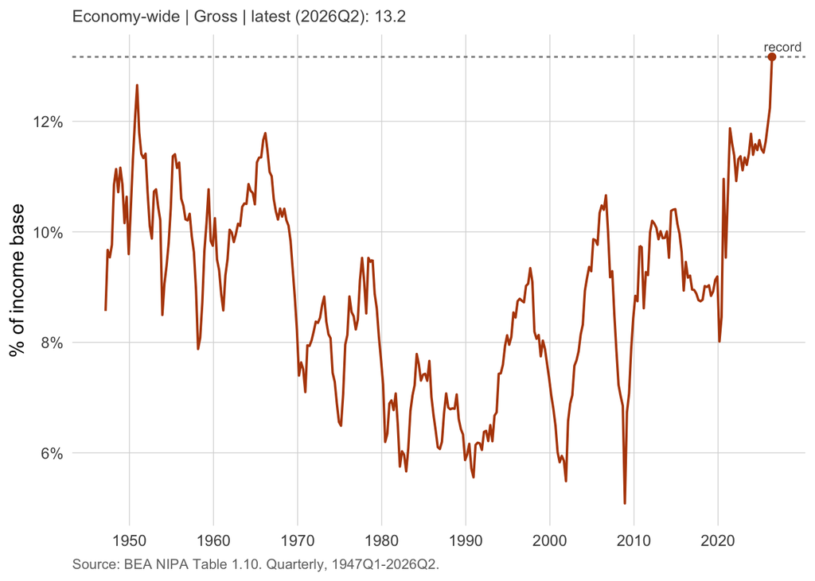

```r
print(plot_measure("p_all_pretax_gdi", "high"))
```

### Corporate business (all corporations)

```r
for (id_ in c("p_all_pretax_gross", "p_all_pretax_net", "p_all_aftertax_gross", "p_all_aftertax_net")) {
  cat(sprintf("\n\n#### %s\n\n", meta$name[meta$id == id_]))
  print(plot_measure(id_, "high"))
}
```

#### Corporate profit margin, pretax, gross

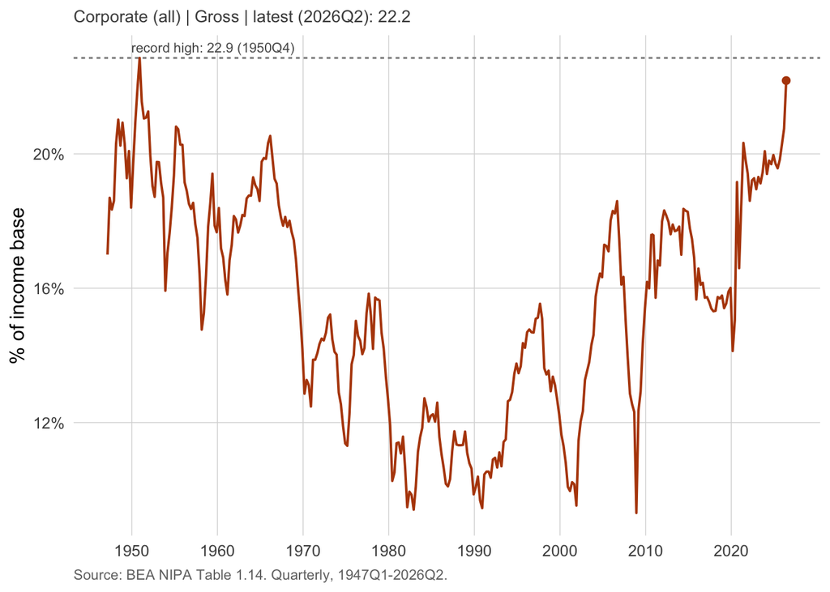

#### Corporate profit margin, pretax, net

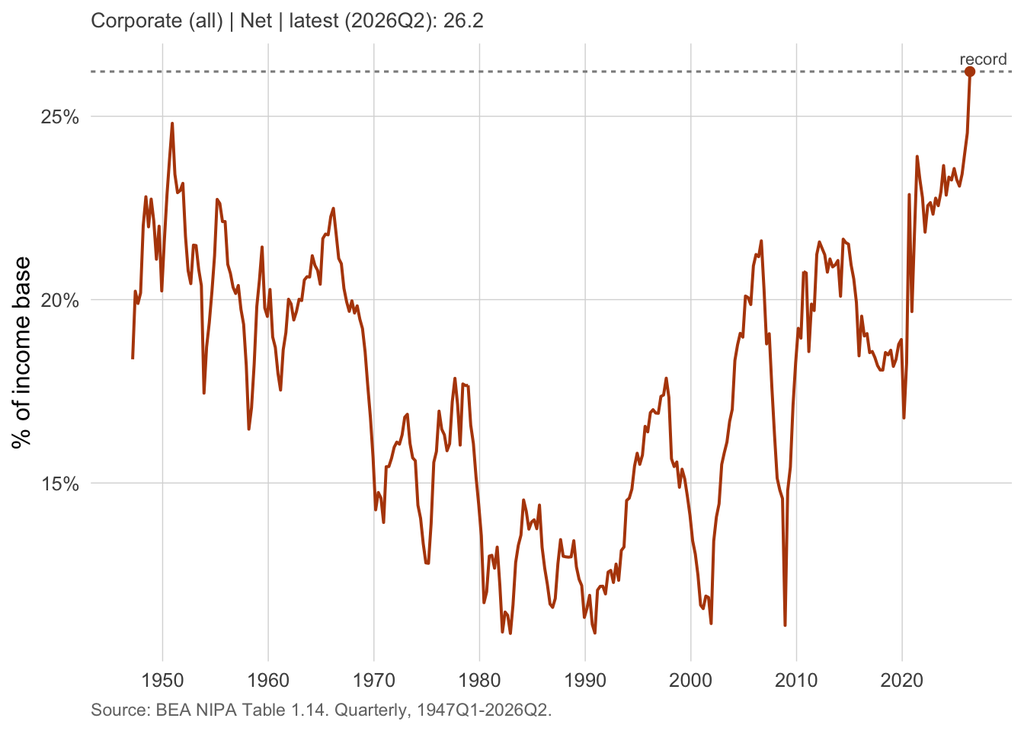

#### Corporate profit margin, after tax, gross

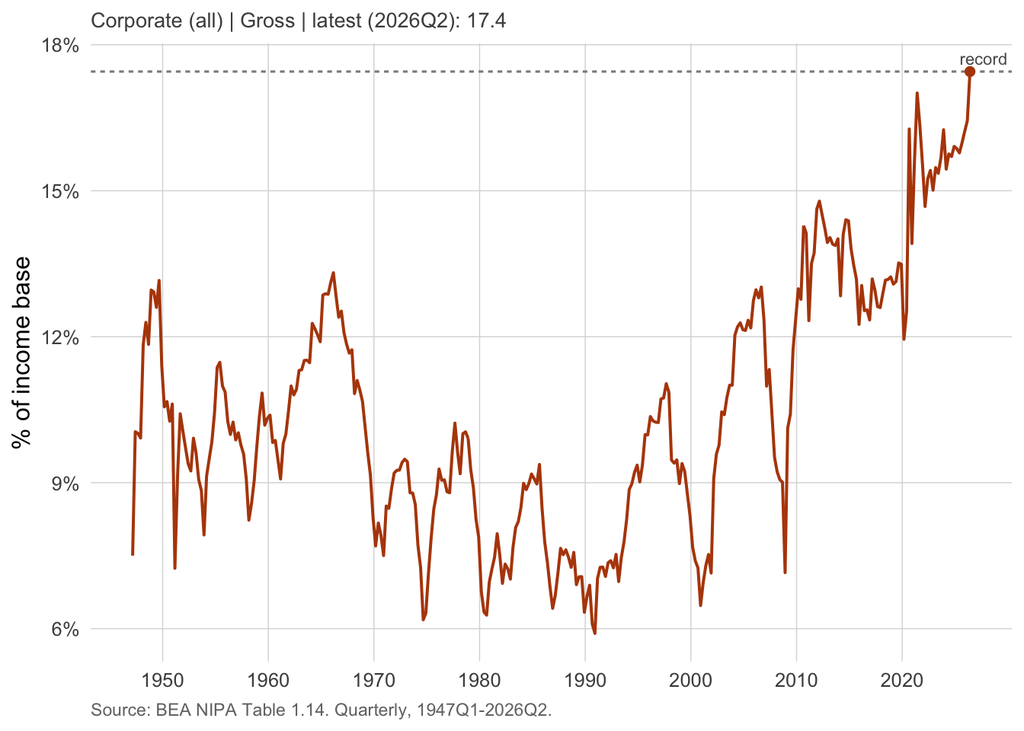

#### Corporate profit margin, after tax, net

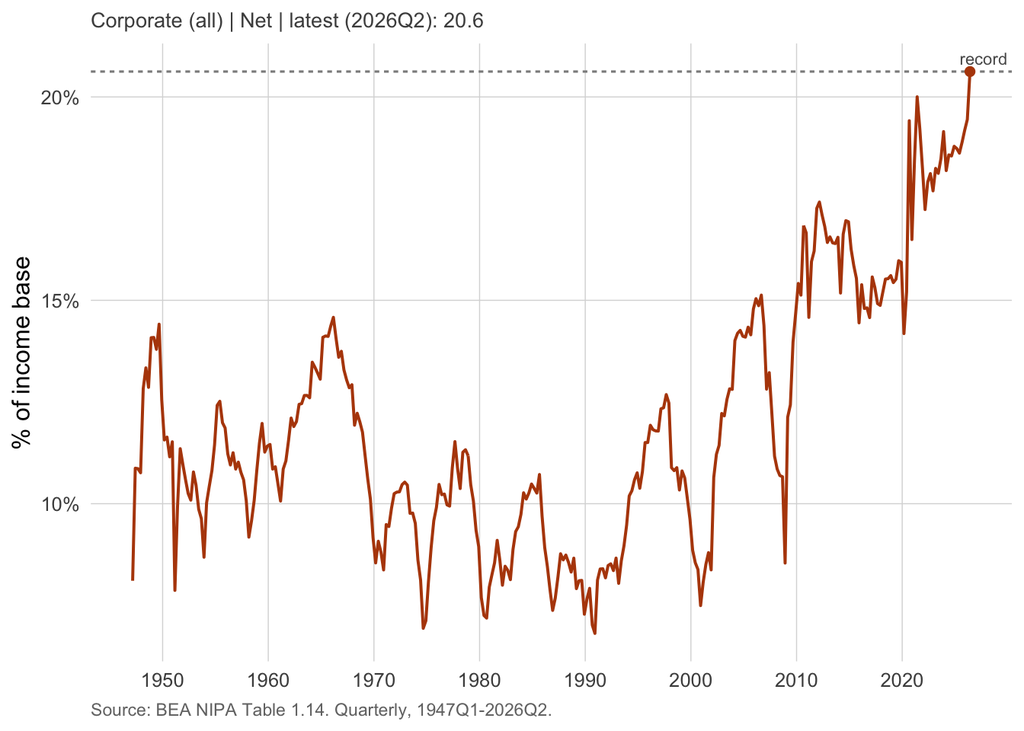

### Nonfinancial corporate business

Slide 2 of the internal deck charts the first of these (pretax, gross) to argue profits “remain elevated” post-pandemic; the other three vary the tax and depreciation treatment.

```r
for (id_ in c("p_nf_pretax_gross", "p_nf_pretax_net", "p_nf_aftertax_gross", "p_nf_nos_net")) {
  cat(sprintf("\n\n#### %s\n\n", meta$name[meta$id == id_]))
  print(plot_measure(id_, "high"))
}
```

#### Nonfinancial corporate profit margin, pretax, gross

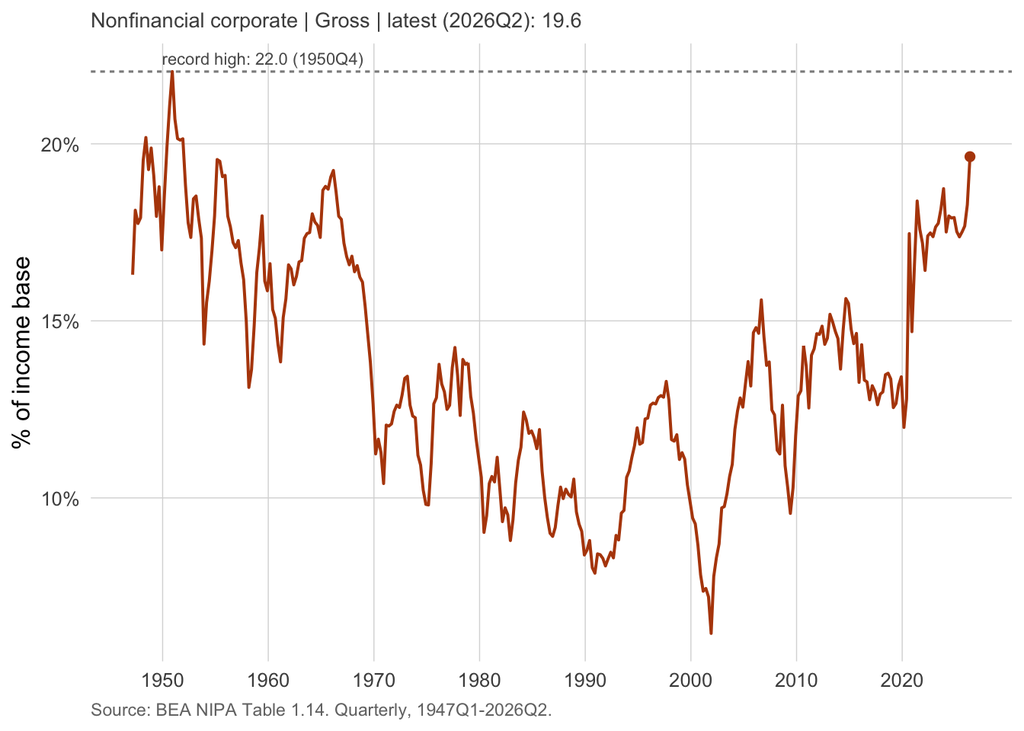

#### Nonfinancial corporate profit margin, pretax, net

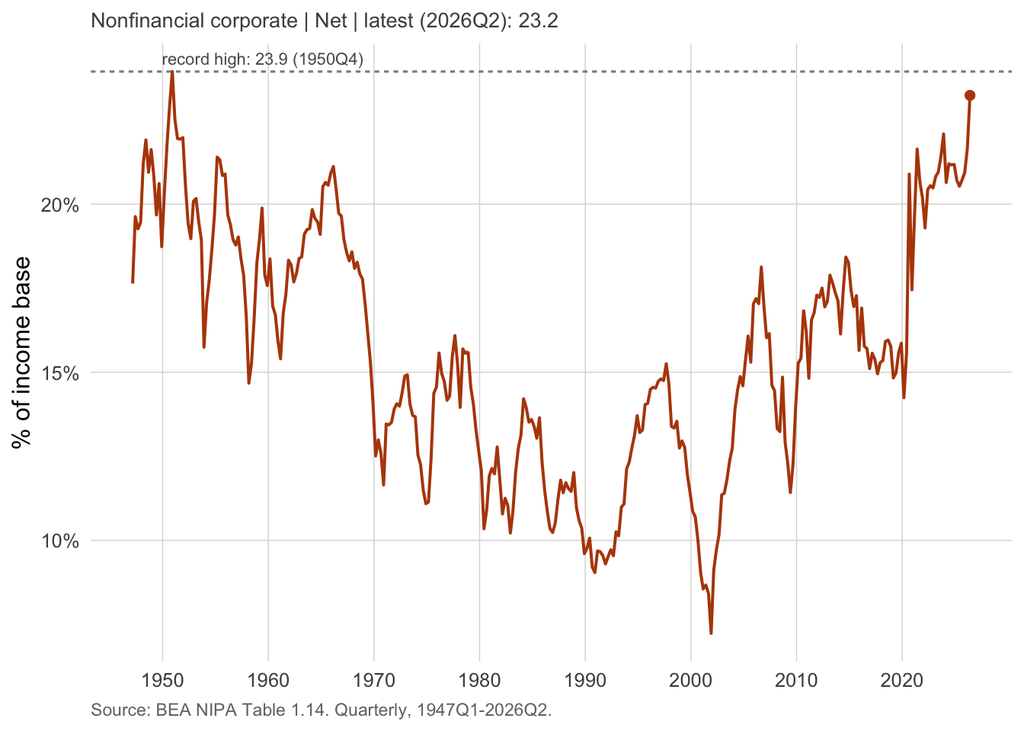

#### Nonfinancial corporate profit margin, after tax, gross

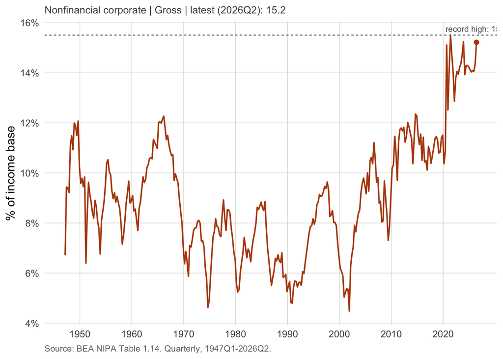

#### Nonfinancial net operating surplus, net

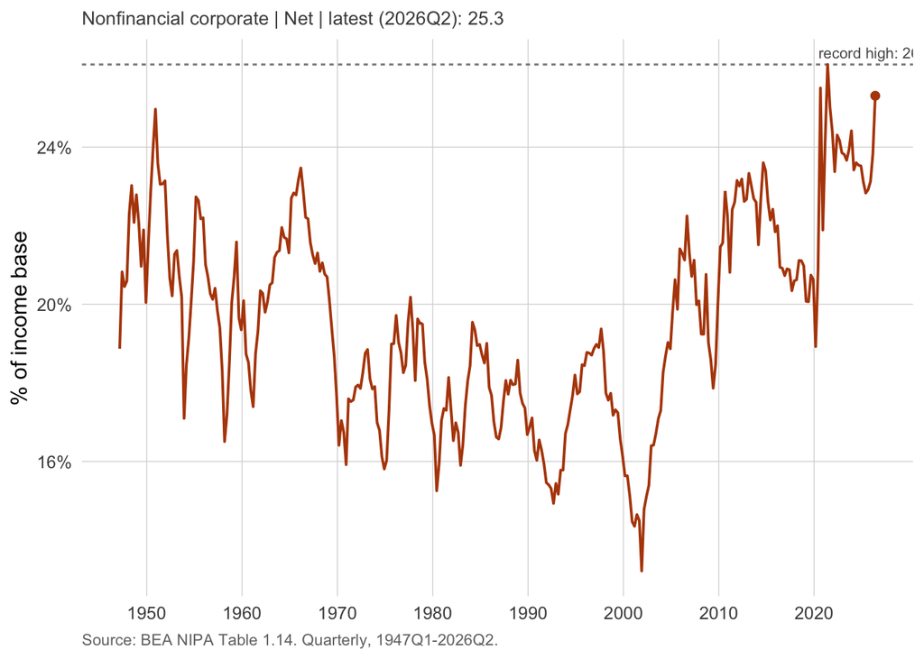

### Corporate profits: is it a record high?

```r
profit_order <- c("p_all_pretax_gdi", "p_all_pretax_gross", "p_all_pretax_net",
                   "p_all_aftertax_gross", "p_all_aftertax_net",
                   "p_nf_pretax_gross", "p_nf_pretax_net", "p_nf_aftertax_gross", "p_nf_nos_net")
make_table(profit_order, "high")
```

| Name | Description | Is it the highest? | Context |
| --- | --- | --- | --- |
| Corporate profits (pretax) as a share of GDI | Corporate profits with IVA & CCAdj, all corporations / gross domestic income - the whole-economy "profits as a share of GDP" framing common in press coverage. | Yes - record high | Record high of the quarterly series (1947Q1-2026Q2). Previous high was 12.7 in 1950Q4, so this is 0.5 above that. |
| Corporate profit margin, pretax, gross | Corporate profits with IVA & CCAdj / gross value added, all corporations. | No | 2nd-highest of 318 quarters since 1947Q1; 0.7 below the record high set in 1950Q4. |
| Corporate profit margin, pretax, net | Corporate profits with IVA & CCAdj / net value added, all corporations. | Yes - record high | Record high of the quarterly series (1947Q1-2026Q2). Previous high was 24.8 in 1950Q4, so this is 1.4 above that. |
| Corporate profit margin, after tax, gross | Corporate profits after tax with IVA & CCAdj / gross value added, all corporations. | Yes - record high | Record high of the quarterly series (1947Q1-2026Q2). Previous high was 17.0 in 2021Q2, so this is 0.4 above that. |
| Corporate profit margin, after tax, net | Corporate profits after tax with IVA & CCAdj / net value added, all corporations. | Yes - record high | Record high of the quarterly series (1947Q1-2026Q2). Previous high was 20.0 in 2021Q2, so this is 0.6 above that. |
| Nonfinancial corporate profit margin, pretax, gross | Corporate profits with IVA & CCAdj / gross value added, nonfinancial corporate business only. This is the exact construction behind the deck's slide 2 chart ("Corporate Profits Remain Elevated"). | No | In the top decile of its own history (97th percentile from the bottom); 2.4 below the record high set in 1950Q4. |
| Nonfinancial corporate profit margin, pretax, net | Corporate profits with IVA & CCAdj / net value added, nonfinancial corporate business. | No | 2nd-highest of 318 quarters since 1947Q1; 0.7 below the record high set in 1950Q4. |
| Nonfinancial corporate profit margin, after tax, gross | Corporate profits after tax with IVA & CCAdj / gross value added, nonfinancial corporate business. | No | 3rd-highest of 318 quarters since 1947Q1; 0.3 below the record high set in 2021Q2. |
| Nonfinancial net operating surplus, net | Net operating surplus (profits + net interest + business transfer payments - the broadest NIPA capital-income aggregate) / net value added, nonfinancial corporate business. | No | 3rd-highest of 318 quarters since 1947Q1; 0.8 below the record high set in 2021Q2. |

```r
prof_rk        <- rk |> filter(id %in% profit_order)
n_profit_high  <- sum(prof_rk$is_record_high)
high_names     <- prof_rk$name[prof_rk$is_record_high]
nf_rk          <- prof_rk |> filter(sector == "Nonfinancial corporate")
nf_rank_range  <- range(nf_rk$rank_high)
```

## What this does and doesn’t settle

Twelve labor-share conventions and nine corporate-profit conventions, spanning gross/net, four sector universes and three proprietor-income allocations, agree that both series sit at or extremely near an 80-year extreme as of 2026Q2. That’s a statement about levels. It says nothing about whether the capital income these measures net out is a competitive return or economic rent – see `docs/replication_and_literature.md` for the markup and superstar-firm literature that speaks to that question, which an aggregate income-share identity can’t answer on its own.